# Mid-HW

Zile Wu&Yuhao Jia

2022-09-30

## Data Wrangling

### Raw Data Descriptions

- Data sources:
  1. Census data from the American Community Survey (ACS)
  2. GIS Data Center，Mecklenberg County, NC. https://www.mecknc.gov/LUESA/GIS/Pages/GIS-Data-Center.aspx
  3. Open Mapping, Mecklenberg County, NC. http://maps.co.mecklenburg.nc.us/openmapping/index.html
- Data Collection:
- Through the visualization of the data, we projected the different house prices on the map of Mecklenberg County using different color points. From the distribution of the price points, we can visually see that prices are higher in the north and south of Mecklenberg County, and lower in the southwest, through the center, and all the way to the east, showing a band of the letter “n”. Although the geoJSON dataset containing house prices includes a lot of important basic pricing information such as the year of construction and the number of bedrooms, the environmental information around the house, such as the occurrence of crime and public facilities, also has an impact on the house prices. Therefore, we use the K-nearest-neighbor method to process some information within Mecklenberg County and add it to our machine learning.

### Feature Engineering

```r
st_c <- st_coordinates
Charlotte2 <- Charlotte %>%
  mutate(Grocery_nn2 = nn_function(st_c(Charlotte), st_c(Grocery), 2),
         Crime_nn4 = nn_function(st_c(Charlotte), st_c(Crime) %>% na.omit(), 4),
         School_nn1 = nn_function(st_c(Charlotte), st_c(School)%>% na.omit(), 1),
         Mall_nn2 = nn_function(st_c(Charlotte), st_c(Mall), 2),
         Park_nn3 = nn_function(st_c(Charlotte), st_c(Parks), 3),
         Bus_nn3 = nn_function(st_c(Charlotte), st_c(bus), 3))

Charlotte3 <- Charlotte2 %>%
  st_join(zoning) %>%
  st_join(ZIP) %>%
  st_join(tracts2021) %>%
  st_join(npa) %>%
  mutate(builtTime = case_when(
    yearbuilt >= 2015 ~ "New",
    yearbuilt > 2000 & yearbuilt < 2015 ~ "Recent",
    yearbuilt <= 2000 ~ "Old"  )) %>%
  mutate(numfpla = case_when(
    numfirepla >=3 ~ "many",
    numfirepla > 0 & numfirepla <3 ~ "less2",
    numfirepla == 0 ~ "No"  ))


Charlotte4 <- Charlotte3%>%
  filter(toPredict != 'CHALLENGE')%>%
  st_drop_geometry
Charlotte4$fullbaths <- as.character(Charlotte4$fullbaths)
Charlotte4$halfbaths <- as.character(Charlotte4$halfbaths)
Charlotte4$units <- as.character(Charlotte4$units)
Charlotte4$bedrooms <- as.character(Charlotte4$bedrooms)
Charlotte4$yearbuilt <- as.character(Charlotte4$yearbuilt)
Charlotte4$npa <- as.character(Charlotte4$npa)


###### Feature Selection
Table <- Charlotte4%>%
   dplyr::select(Grocery_nn2,Park_nn3,Bus_nn3, School_nn1,Crime_nn4, Mall_nn2,bedrooms, fullbaths,heatedarea, halfbaths, shape_Area, units, price,  cdebuildin,heatedfuel,bldggrade, totalac, builtTime,extwall,foundation,numfpla,MedHHInc,pctWhite,pctPoverty,pctBlack,pctHispanic,ZIP)
```

- The factors that influence the price of a house fall into three main categories:the properties of the house itself, the urban public services accessible around the house, and the specific spatial structure within the area. Therefore, the variables we use for modeling are also mainly these three categories.
- 1.Internal Characteristics First we looked at the internal characteristics of the houses. We considered features associated with the number of bedrooms, number of bathrooms, living square feet, actual square feet, year built, story-height, units, building type, heated fuel, the structure quality, wall material, number of fire places and foundation type. We took most of them as categorical variables in our model.

```r
internal <- Table%>%
   dplyr::select(bedrooms, fullbaths,heatedarea, halfbaths, shape_Area, units, cdebuildin,heatedfuel,bldggrade, totalac, builtTime, extwall, foundation, numfpla)

stargazer(st_drop_geometry(internal),
          type = 'text',
          title = "Numeric Internal Features",
          covariate.labels = c())
```

```
##
## Numeric Internal Features
## ===============================================================
## Statistic    N       Mean     St. Dev.     Min         Max
## ---------------------------------------------------------------
## heatedarea 46,083 2,359.402  1,060.681    0.000    14,710.000
## shape_Area 46,083 15,872.850 35,058.410 1,139.637 3,486,865.000
## totalac    46,083   1.775     106.833     0.000     9,757.440
## ---------------------------------------------------------------
```

```r
Amenities <- Table %>%
   dplyr::select(Grocery_nn2,Park_nn3,Bus_nn3, School_nn1,Crime_nn4, Mall_nn2)

stargazer(st_drop_geometry(Amenities),
          type = 'text',
          title = "Amenities Features",
          covariate.labels = c())
```

```
##
## Amenities Features
## =========================================================
## Statistic     N      Mean    St. Dev.    Min      Max
## ---------------------------------------------------------
## Grocery_nn2 46,083 6,610.182 4,176.016 438.342 28,608.460
## Park_nn3    46,083 5,701.951 2,671.000 296.326 17,024.180
## Bus_nn3     46,083 4,943.569 4,663.943 144.973 32,668.800
## School_nn1  46,083 4,062.715 2,708.480 64.186  20,333.820
## Crime_nn4   46,083 2,301.561 3,996.468 50.171  24,620.840
## Mall_nn2    46,083 6,695.646 4,325.880 372.942 31,974.730
## ---------------------------------------------------------
```

- 3.Spatial Process House prices are correlated with each other due to the influence of a particular spatial process, so we use spatial structure as a factor affecting house prices as well. The spatial process we consider includes: zip area, land use, income, racial segregation.

```r
Spatial <- Table %>%
   dplyr::select(MedHHInc,pctWhite,pctPoverty,pctBlack,pctHispanic,ZIP)

stargazer(st_drop_geometry(Spatial),
          type = "text",
          title = "Spatial Process Features",
          covariate.labels = c())
```

```
##
## Spatial Process Features
## =======================================================
## Statistic     N       Mean     St. Dev.   Min     Max
## -------------------------------------------------------
## MedHHInc    46,080 86,180.690 37,419.720 17,685 238,750
## pctWhite    46,080   0.571      0.270    0.011   1.710
## pctPoverty  46,080   0.091      0.082    0.000   0.614
## pctBlack    46,080   0.299      0.239    0.000   1.346
## pctHispanic 46,080   0.114      0.099    0.000   0.655
## -------------------------------------------------------
```

### Exploratory Analysis

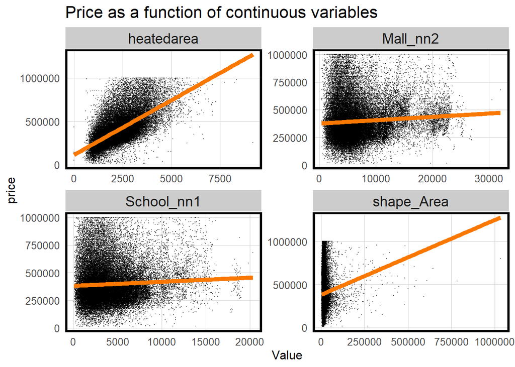

```r
## home plots scatterplots (1 point)
     st_drop_geometry(Table) %>%
     dplyr::select(price, shape_Area,heatedarea,Mall_nn2,School_nn1) %>%
     filter(price <= 1000000) %>%
     gather(Variable, Value, -price) %>%
     ggplot(aes(Value, price)) +
     geom_point(size = .05,alpha=0.5) + geom_smooth(method = "lm", se=F, colour = "#FA7800",size=2) +
     facet_wrap(~Variable, ncol = 2, scales = "free") +
     labs(title = "Price as a function of continuous variables") +
     plotTheme()
```

- In consideration of model training efficiency, only one set of data is selected to be added to the model training in the K-nearest-neighbor method. Since some rating indicators of houses, such as overall maintenance, are more likely to have a direct impact on house prices than some numerical parameters, such as distance to parks & stores, fewer parameters appear in the Correlation matrix, and except for the strong correlation between percent of White and percent of Black, the rest of the data do not show a strong correlation and can be be used as parameters for model training.

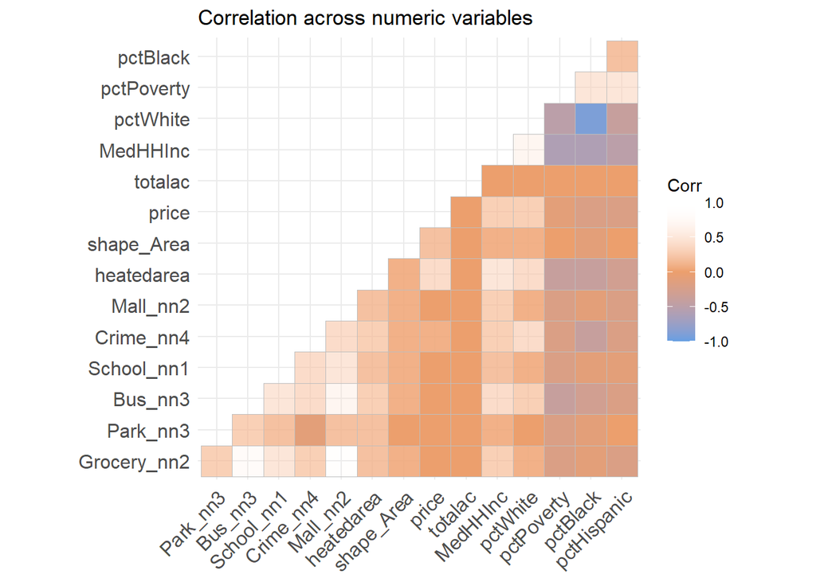

```r
## Correlation Matrix(0.5 point)
numericVars <-
  select_if(st_drop_geometry(Table), is.numeric) %>% na.omit()

ggcorrplot(
  round(cor(numericVars), 1),
  p.mat = cor_pmat(numericVars),
  colors = c("#659FE3", "#EC9F6D"),
  type="lower",
  insig = "blank") +
  labs(title = "Correlation across numeric variables")
```

### Data Mapping

- We first visualized the home price to have a rough idea about the spatial pattern.

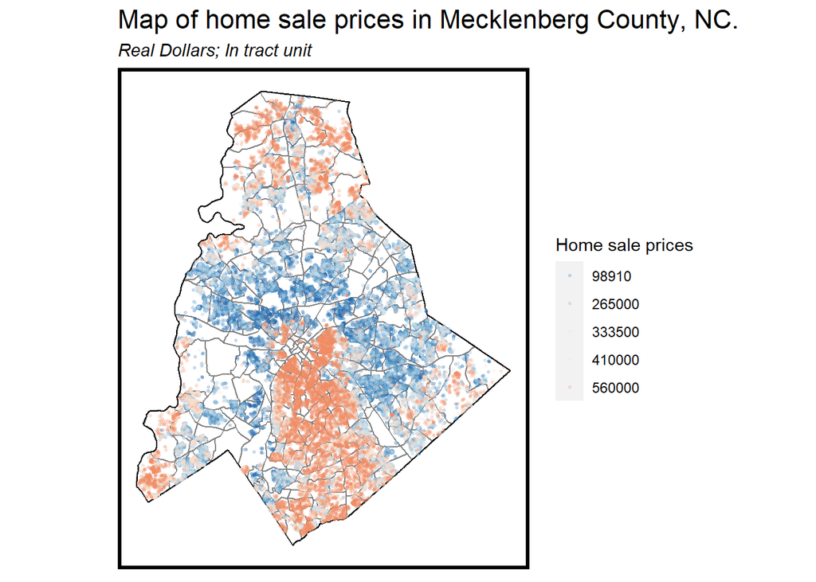

```r
## Map home prices (0.5 point)
ggplot()+
  geom_sf(data = tracts2021, color="gray50",fill = "transparent",size=0.5)+
  geom_sf(data = boundary,fill = "transparent", color="black",size=0.5)+
  geom_sf(data = Charlotte, aes(color = q5(price)), size = 0.5,alpha=0.2)+
  scale_color_manual(values = palette6,
                    labels = qBr(Charlotte, "price"),
                    name = "Home sale prices")+
  labs(title = "Map of home sale prices in Mecklenberg County, NC.",
       subtitle = "Real Dollars; In tract unit")+
  mapTheme()
```

[figure not shown]

```r
## 3 interesting maps
Tableinterest = Table %>%
  gather(key,value, -price)

# 1
Tableinterest1 <- Tableinterest %>% filter(key == "heatedarea")
ggplot(Tableinterest1, aes(x = value, y = price))+
  geom_point(size=3,shape = 21, fill = "#69b3a2",alpha=0.3)+
  geom_smooth(method = lm, se=F,colour = "#DC986D",size=5)+
  labs(title="Scatter plot of price to heatedarea") +
  plotTheme()+
  theme(axis.text=element_text(size=12),axis.title=element_text(size=2))
```

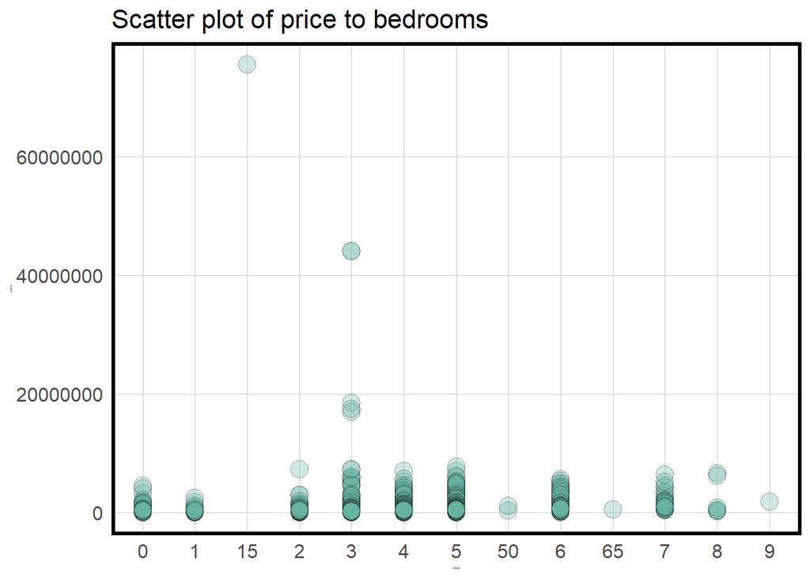

```r
# 2
Tableinterest2 <- Tableinterest %>% filter(key == "bedrooms")
ggplot(Tableinterest2, aes(x = value, y = price))+
  geom_point(size=5,shape = 21, fill = "#69b3a2",alpha=0.3)+
  geom_smooth(method = lm, se=F,colour = "#DC986D",size=2)+
  labs(title="Scatter plot of price to bedrooms") +
  plotTheme()+
  theme(axis.text=element_text(size=12),axis.title=element_text(size=2))
```

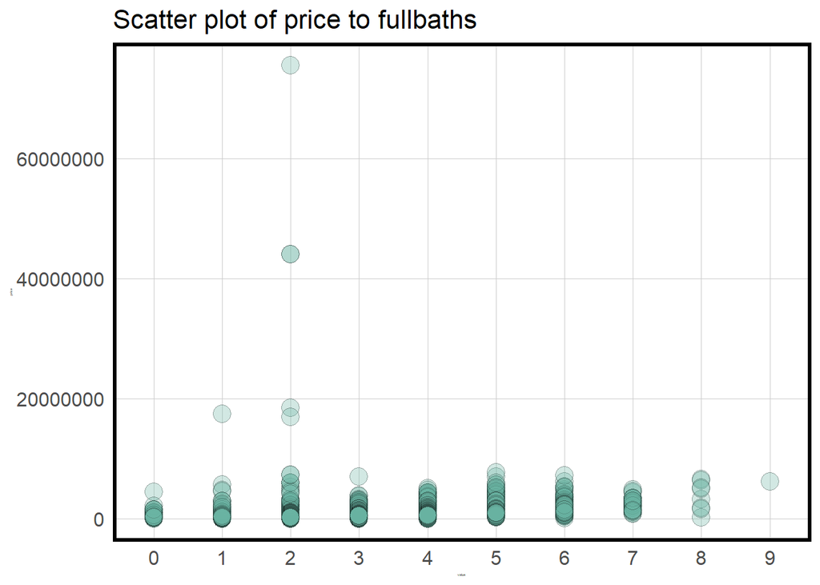

```r
# 3
Tableinterest3 <- Tableinterest %>% filter(key == "fullbaths")
ggplot(Tableinterest3, aes(x = value, y = price))+
  geom_point(size=5,shape = 21, fill = "#69b3a2",alpha=0.3)+
  geom_smooth(method = lm, se=F,colour = "red",size=5)+
  labs(title="Scatter plot of price to fullbaths") +
  plotTheme()+
  theme(axis.text=element_text(size=12),axis.title=element_text(size=2))
```

- Here we use buffers to try to find the link between parks, a public amenity, and the home of house prices, however the results do not show the presence of park buffers in both areas with higher and lower house prices, indicating that the effect of parks on house prices does not seem to be strong.

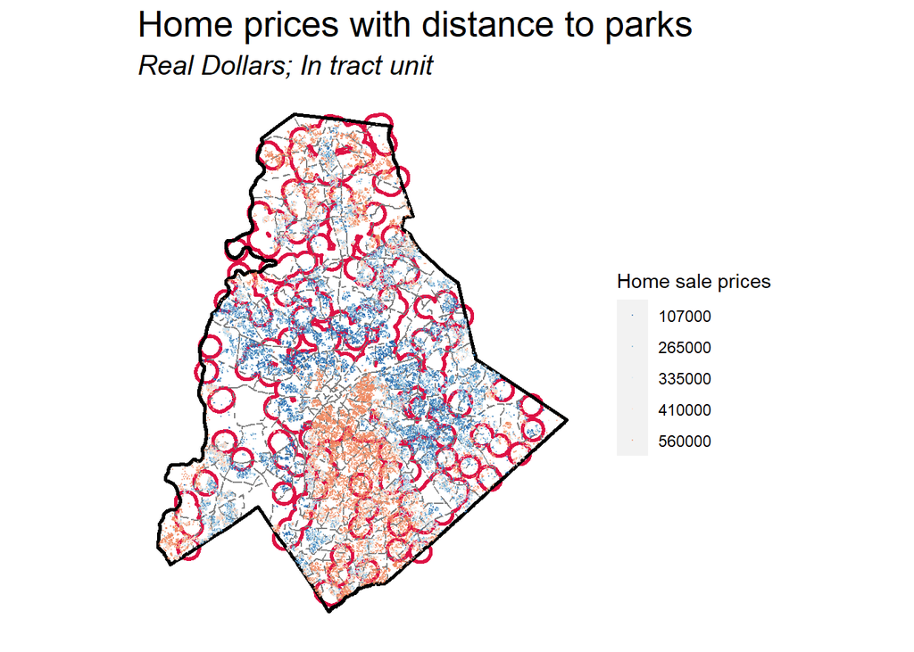

```r
#Bonus for something extra engaging(0.5 point)

parksunion <- st_buffer(st_union(Parks),500)%>%st_sf()
parksunion2 <- st_buffer(st_union(Parks),2000)%>%st_sf()
parksunion3 <- st_buffer(st_union(Parks),4000)%>%st_sf()
ggplot()+
  geom_sf(data = parksunion3, color="#DD1144", size = 1,fill="white")+
  geom_sf(data = tracts2021,color="gray50",fill = "transparent",size=0.5,linetype = "dashed")+
  geom_sf(data = boundary,fill = "transparent",color="black",size=1)+
  geom_sf(data = Charlotte, aes(color = q5(price)), size = 0.01,alpha=0.5)+
  scale_color_manual(values = palette6,
                    labels = qBr(Table, "price"),
                    name = "Home sale prices")+
  labs(
    title = "Home prices with distance to parks",
    subtitle = "Real Dollars; In tract unit") +
  mapTheme() +
  theme(
    plot.title = element_text(size = 20),
    plot.subtitle=element_text(size = 15,face="italic"),
    panel.border = element_blank(),
    axis.text = element_blank(),
    panel.background = element_blank(),
    panel.grid = element_blank(),
    axis.ticks = element_blank())
```

## Method

This house price forecasting model uses an OLS regression model, also known as least squares regression. The objective is to minimize the sum of squares of the difference between the observed values and the fitted values provided by the model. In the actual model, we use multivariate spatial data to forecast housing prices in Mecklenberg County, NC. The whole forecasting process is divided into three parts, 1. forecasting parameter selection, 2. forecasting model training, and 3. model prediction.

- 1. Forecasting parameter selection. Firstly, we use the background knowledge of architecture and urban planning to make the initial selection of parameters. Secondly, the parameters are further selected by using Correlation Matrix and Home prices scatterplots.
- 2. Forecasting model training. Firstly, the model is trained using least squares regression. According to the R^2 of the model and the data of the test set, the parameters of the model are adjusted to keep the error rate in a low range.
- 3. Model prediction. Based on the trained model, input the geoJSON information of the house to be predicted, and automatically generate the predicted price of the house.

## Result

### Machine Learning & OLS Regression Model

```r
## Train Results
Table <- Table %>%
  dplyr::select(Grocery_nn2,Park_nn3,Bus_nn3, School_nn1,Crime_nn4, Mall_nn2,bedrooms, fullbaths,heatedarea, halfbaths, shape_Area, units, price,  cdebuildin,heatedfuel,bldggrade, totalac, builtTime,extwall,foundation,numfpla,MedHHInc,pctWhite,pctPoverty,pctHispanic,ZIP)

inTrain <- createDataPartition(
              y = paste(Table$cdebuildin, Table$codemunici,Table$heatedfuel, Table$bldggrade, Table$builtTime, Table$fullbaths, Table$halfbaths, Table$units, Table$bedrooms, Table$actype, Table$extwall, Table$foundation, Table$fireplaces, Table$numfpla,Table$typeofdeed, Table$landusecod, Table$accounttyp, Table$landsequen,Table$ZIP),
              p = .60, list = FALSE)
Table.training <- Table[inTrain,]
Table.test <- Table[-inTrain,]

reg.training <- lm(price ~ ., data = Table.training)

Table.test <-
  Table.test %>%
  mutate(SalePrice.Predict = predict(reg.training, Table.test),
         SalePrice.Error = SalePrice.Predict - price,
         SalePrice.AbsError = abs(SalePrice.Predict - price),
         SalePrice.APE = (abs(SalePrice.Predict - price)) / SalePrice.Predict)%>%
  filter(price < 5000000)

MAE <- mean(Table.test$SalePrice.AbsError, na.rm = T)
MAPE <- mean(Table.test$SalePrice.APE, na.rm = T)
MAE = c(MAE) %>% format(., digits = 3)
MAPE = c(MAPE) %>% format(., digits = 3)
Model = c("Model with Tract ID", "Model with Spatial Lag")
summaryTable1 = cbind(Model, MAE, MAPE)
```

- Table of results(training set) After selecting the completed training set parameters, the following are the results of the training set training.

```r
##Table of results(0.5point)
stargazer(st_drop_geometry(reg.training),
          type = 'text',
          title = "OLS Regression",
          covariate.labels = c())
```

```
##
## OLS Regression
## =========================================================
##                                  Dependent variable:
##                              ----------------------------
##                                         price
## ---------------------------------------------------------
## Grocery_nn2                            7.602***
##                                        (1.757)
##
## Park_nn3                               3.566***
##                                        (1.074)
##
## Bus_nn3                               -7.720***
##                                        (0.869)
##
## School_nn1                              1.065
##                                        (0.960)
##
## Crime_nn4                             12.740***
##                                        (1.121)
##
## Mall_nn2                              -9.395***
##                                        (1.667)
##
## bedrooms1                            108,932.900*
##                                      (64,079.630)
##
## bedrooms15                        73,005,267.000***
##                                     (364,084.700)
##
## bedrooms2                            54,039.760*
##                                      (31,546.480)
##
## bedrooms3                            54,292.190*
##                                      (30,663.720)
##
## bedrooms4                             22,594.740
##                                      (30,722.600)
##
```

[output cut: 326 more lines]

```
##
## ZIP28278                            -69,113.370***
##                                      (20,373.470)
##
## Constant                             -92,794.800
##                                      (57,608.410)
##
## ---------------------------------------------------------
## Observations                            32,980
## R2                                      0.705
## Adjusted R2                             0.704
## Residual Std. Error            354,291.000 (df = 32859)
## F Statistic                  654.505*** (df = 120; 32859)
## =========================================================
## Note:                         *p<0.1; **p<0.05; ***p<0.01
```

```r
kable(summaryTable1, digits = 1, caption = "Table. Prediction precision of the first two models") %>%
  kable_classic(full_width = T)%>%
  footnote()
```

Table. Prediction precision of the first two models

[output not shown]

### Accuracy

- The following are the results of Cross-Validation Cross-validation, sometimes called round-robin estimation, is a statistically useful method for cutting data samples into smaller subsets. The analysis can then be done on one subset first, while the other subsets are used for subsequent confirmation and validation of this analysis. The initial subset is called the training set. The other subsets are called the validation set or test set. Here we perform 100-fold cross-validation.It can be used to determine the average goodness of fit of the model.The results of cross-validation show that the MAE of the model is around 100,000, which, together with the compact distribution of MAE, indicates that the model has a good fit, which means it’s powerful.

```r
###Cross-Validation
fitControl <- trainControl(method = "cv", number = 100)
set.seed(825)

reg.cv <-
  train(price ~ ., data = Table,
     method = "lm", trControl = fitControl, na.action = na.pass)

data.frame(Test = c("Cross_Validation"),
           Mean = mean(reg.cv$resample[,3]),
           Max = max(reg.cv$resample[,3]),
           Min = min(reg.cv$resample[,3]),
           Standard_Deviation = sd(reg.cv$resample[,3]))%>%
  kable() %>%
  kable_styling() %>%
  footnote(general_title = "Summary Statistics of Cross Validation, k = 100 folds",
           general = "Table")
```

| Test | Mean | Max | Min | Standard_Deviation |
| --- | --- | --- | --- | --- |
| Cross_Validation | 105617.4 | 262458.7 | 82653.56 | 22714.22 |

Summary Statistics of Cross Validation, k = 100 folds  
Table

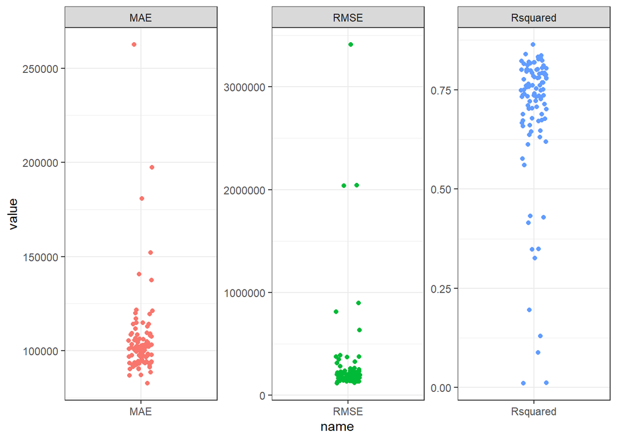

```r
reg.cv$resample %>%
  pivot_longer(-Resample) %>%
  mutate(name = as.factor(name)) %>%
  ggplot(., aes(x = name, y = value, color = name)) +
  geom_jitter(width = 0.1) +
  facet_wrap(~name, ncol = 3, scales = "free") +
  theme_bw() +
  theme(
    legend.position = "none"
  )
```

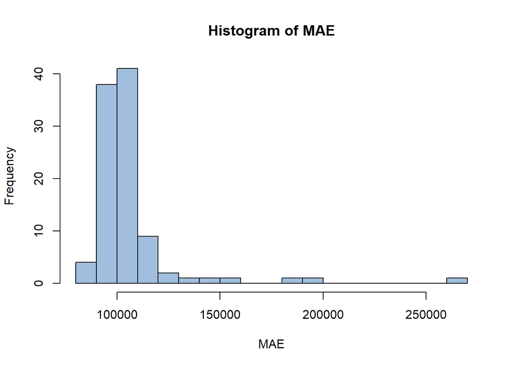

```r
hist(reg.cv$resample[,3],xlab="MAE", col="#A2BEDF", breaks = 20, main = "Histogram of MAE")
```

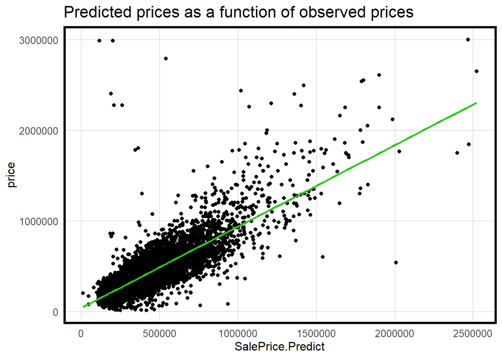

```r
Table.test %>%
ggplot(aes(SalePrice.Predict, price))+
geom_point() +
stat_smooth(aes(SalePrice.Predict, price),
            method = "lm", se = FALSE, size = 1, colour="#25CB10")+
labs(title="Predicted prices as a function of observed prices") +
plotTheme()
```

### Check Cluster & Neighborhood Effects

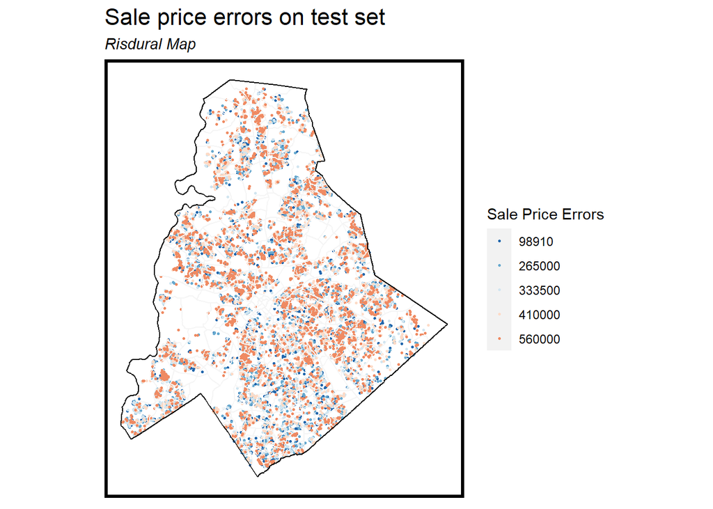

```r
###risdural map
errorToPlot <- Charlotte2 %>%
  left_join(Table.test, by = "Grocery_nn2") %>%
  filter(SalePrice.AbsError != 0) %>%
  dplyr::select(SalePrice.AbsError,SalePrice.APE)


ggplot() +
    geom_sf(data=errorToPlot,  aes(color = q5(SalePrice.APE)), size=0.5)+
    geom_sf(data = tracts2021, color="gray96",fill = "transparent",size=0.5)+
    geom_sf(data = boundary,fill = "transparent", color="black")+
    scale_color_manual(values = palette6,
                    labels = qBr(Charlotte, "price"),
                    name = "Sale Price Errors")+
    labs(title = "Sale price errors on test set",
       subtitle = "Risdural Map")+
     mapTheme()
```

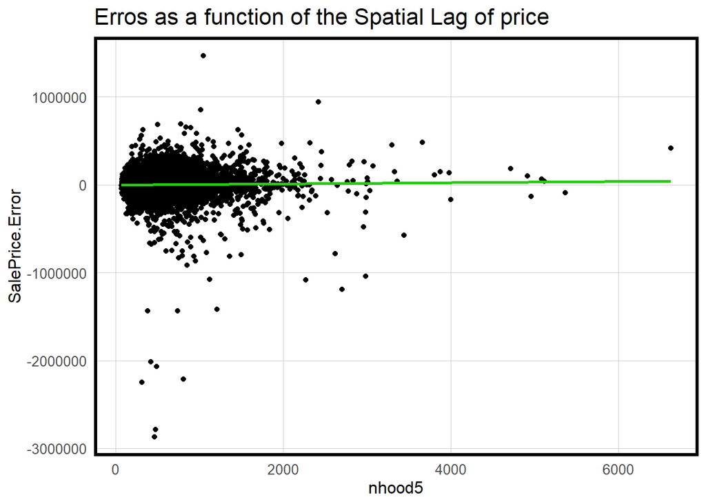

```r
##Spatial Lag
Table.testshp <- dplyr::select(Charlotte2, Grocery_nn2) %>%
  left_join(Table.test, by = "Grocery_nn2") %>%
  na.omit()
coords.test <-  st_coordinates(Table.testshp)
neighborList.test <- knn2nb(knearneigh(coords.test, 5))
spatialWeights.test <- nb2listw(neighborList.test, style="W")

Lag <- Table.testshp%>%
  mutate(nhood5 = nn_function(coords.test, coords.test, 6))

ggplot(Lag, aes(nhood5,SalePrice.Error))+
geom_point() +
stat_smooth(aes(nhood5,SalePrice.Error),
            method = "lm", se = FALSE, size = 1, colour="#25CB10")+
labs(title="Erros as a function of the Spatial Lag of price") +
plotTheme()
```

```r
###Moran's I

moranTest <- moran.mc(Table.testshp$SalePrice.Error,
                      spatialWeights.test, nsim = 999)
moranTest
```

```
##
##  Monte-Carlo simulation of Moran I
##
## data:  Table.testshp$SalePrice.Error
## weights: spatialWeights.test
## number of simulations + 1: 1000
##
## statistic = 0.20538, observed rank = 1000, p-value = 0.001
## alternative hypothesis: greater
```

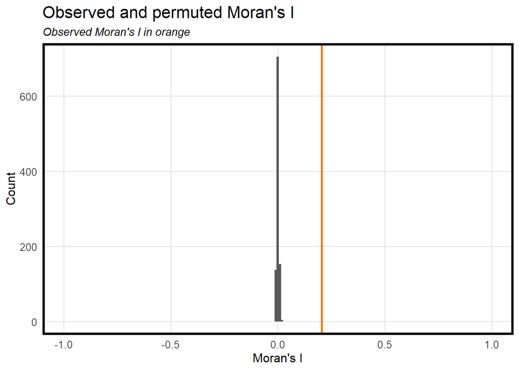

```r
ggplot(as.data.frame(moranTest$res[c(1:999)]), aes(moranTest$res[c(1:999)])) +
  geom_histogram(binwidth = 0.01) +
  geom_vline(aes(xintercept = moranTest$statistic), colour = "#FA7800",size=1) +
  scale_x_continuous(limits = c(-1, 1)) +
  labs(title="Observed and permuted Moran's I",
       subtitle= "Observed Moran's I in orange",
       x="Moran's I",
       y="Count") +
  plotTheme()
```

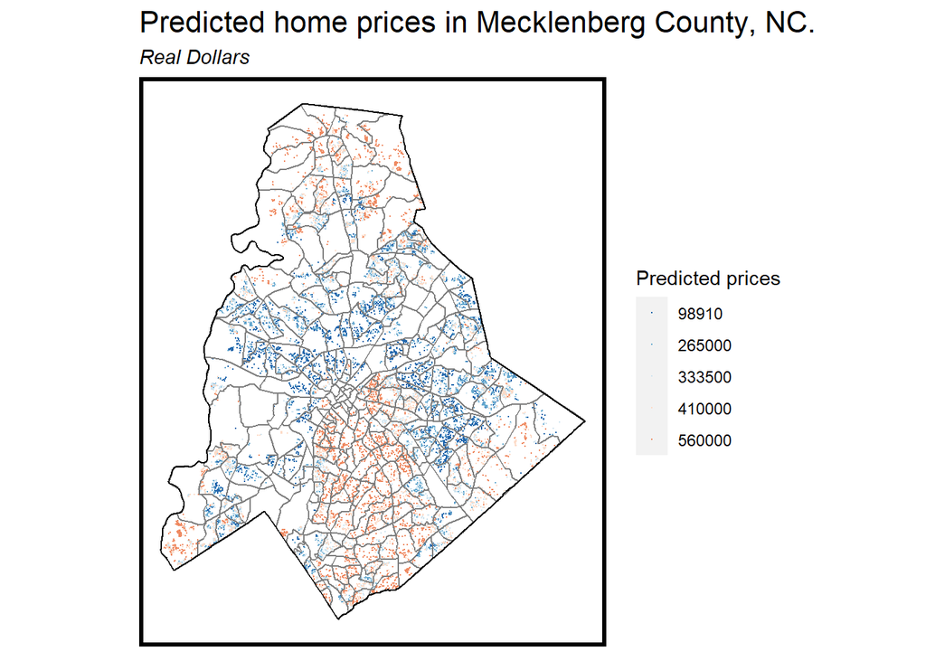

```r
ggplot() +
  geom_sf(data=Table.testshp,  aes(color = q5(SalePrice.Predict)), size=0.1)+
    geom_sf(data = tracts2021, color="gray50",fill = "transparent",size=0.5)+
  geom_sf(data = boundary,fill = "transparent", color="black")+
  scale_color_manual(values = palette6,
                    labels = qBr(Charlotte, "price"),
                    name = "Predicted prices")+
  labs(title = "Predicted home prices in Mecklenberg County, NC.",
       subtitle = "Real Dollars")+
  mapTheme()
```

### Generalizability

- To test the generalizability of the model, we confirm the performance of the model across communities by calculating the average APE of the communities. The results show that there are still individual communities with higher MAPE compared to others.

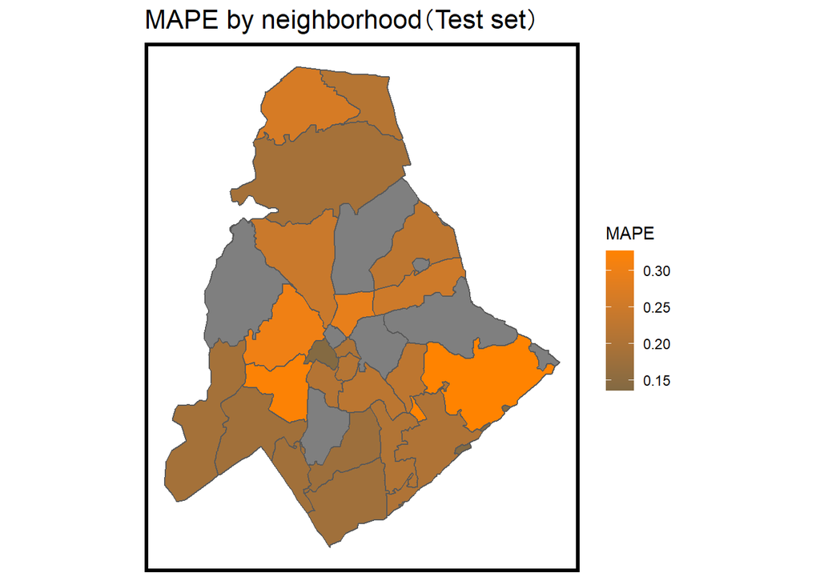

```r
MAPE_nhood <- Table.test %>%
  group_by(ZIP) %>%
  summarise( MAPE= mean(SalePrice.APE),
              Price.mean = mean(price))
MAPE_bynhood <- ZIP %>%
  left_join(MAPE_nhood, by="ZIP")

ggplot() +
    geom_sf(data=MAPE_bynhood,  aes(fill = MAPE))+
    scale_fill_gradient(low = "#826943", high = "#FF8300",
                          name = "MAPE") +
      labs(title = "MAPE by neighborhood（Test set）") +
      mapTheme()
```

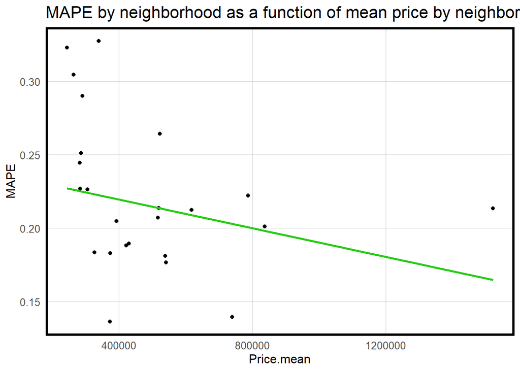

```r
MAPE_bynhood %>%
ggplot(aes(Price.mean, MAPE))+
geom_point() +
stat_smooth(aes(Price.mean, MAPE),
            method = "lm", se = FALSE, size = 1, colour="#25CB10")+
labs(title="MAPE by neighborhood as a function of mean price by neighborhood") +
plotTheme()
```

- We also tested the generalizability of the model across income groups and across races. The results show that the accuracy of the model is similar between the white and non-white groups. In contrast, the accuracy of the models differed more between different income groups. This implies that the generalizability of the model still has some shortcomings.

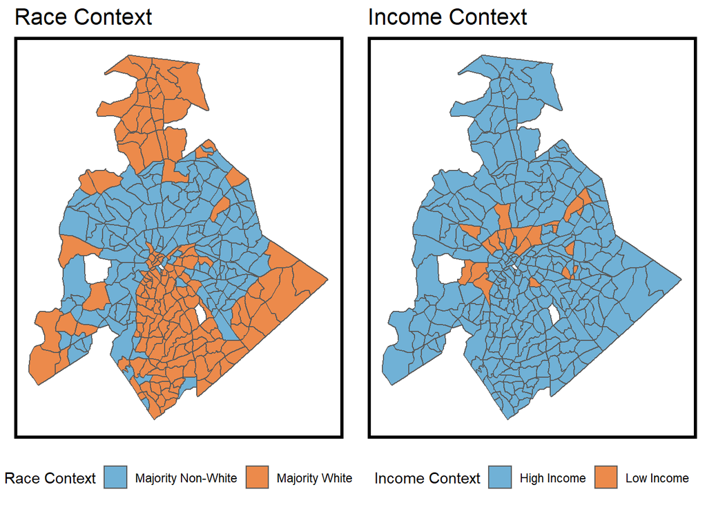

```r
IncomeRace <- tracts2021 %>%
  mutate(raceContext = ifelse(pctWhite > .5, "Majority White", "Majority Non-White"),
         incomeContext = ifelse(MedHHInc > 35000, "High Income", "Low Income"))

grid.arrange(ncol = 2,
  ggplot() + geom_sf(data = na.omit(IncomeRace), aes(fill = raceContext)) +
    scale_fill_manual(values = c("#70B1D6", "#EC8A4B"), name="Race Context") +
    labs(title = "Race Context") +
    mapTheme() + theme(legend.position="bottom"),
  ggplot() + geom_sf(data = na.omit(IncomeRace), aes(fill = incomeContext)) +
    scale_fill_manual(values = c("#70B1D6", "#EC8A4B"), name="Income Context") +
    labs(title = "Income Context") +
    mapTheme() + theme(legend.position="bottom"))
```

```r
st_join(Table.testshp, IncomeRace) %>%
  group_by(raceContext) %>%
  summarize(mean.MAPE = scales::percent(mean(SalePrice.APE, na.rm = T))) %>%
  st_drop_geometry() %>%
  spread(raceContext, mean.MAPE) %>%
  kable(caption = "Test set MAPE by neighborhood racial context") %>%
  kable_styling()
```

Test set MAPE by neighborhood racial context

| Majority Non-White | Majority White |
| --- | --- |
| 23% | 20% |

```r
st_join(Table.testshp, IncomeRace) %>%
  filter(!is.na(incomeContext)) %>%
  group_by(incomeContext) %>%
  summarize(mean.MAPE = scales::percent(mean(SalePrice.APE, na.rm = T))) %>%
  st_drop_geometry() %>%
  spread(incomeContext, mean.MAPE) %>%
  kable(caption = "Test set MAPE by neighborhood income context")%>%
  kable_styling()
```

Test set MAPE by neighborhood income context

| High Income | Low Income |
| --- | --- |
| 21% | 39% |

- In general, although our model exhibits some accuracy and generalizability, it has significant shortcomings. The lack of accuracy is not clear spatially distributted, but there might be smaller scale spatial process that is not taken into considered in this model.The lack of generalizability is mainly reflected in the poor generalizability within different communities and among different income groups. The median income feature in the model doesn’t affect the model that much. We may need to find more detailed income data or other features related to income to avoid this.

## Conclusion & Recommendation

- I would recommend this model to zillow. this model shows some ability while the direction of deficiency is very clear, which makes this model have the potential to be more optimized. I think it can be improved in two ways, one is to find smaller scale spatial process, and the other is to explore the impact of some unconventional thinking features on the model, for example, the per capita tree canopy cover can be considered as an urban amenity into the model.